# What Factors Are Most Associated with Student Academic Success?

Nathan Cao

2026-06-14

## Introduction

The purpose of this project is to determine which factors are most strongly associated with student academic success. Student success will be measured using GPA. By analyzing variables such as study time, absences, parental support, tutoring, and extracurricular activities, I will identify which factors contribute most to academic performance.

## Loading the Data

```r
student <- read.csv("Student_performance_data _.csv")

head(student)
```

```
##   StudentID Age Gender Ethnicity ParentalEducation StudyTimeWeekly Absences
## 1      1001  17      1         0                 2       19.833723        7
## 2      1002  18      0         0                 1       15.408756        0
## 3      1003  15      0         2                 3        4.210570       26
## 4      1004  17      1         0                 3       10.028829       14
## 5      1005  17      1         0                 2        4.672495       17
## 6      1006  18      0         0                 1        8.191219        0
##   Tutoring ParentalSupport Extracurricular Sports Music Volunteering       GPA
## 1        1               2               0      0     1            0 2.9291956
## 2        0               1               0      0     0            0 3.0429148
## 3        0               2               0      0     0            0 0.1126023
## 4        0               3               1      0     0            0 2.0542181
## 5        1               3               0      0     0            0 1.2880612
## 6        0               1               1      0     0            0 3.0841836
##   GradeClass
## 1          2
## 2          1
## 3          4
## 4          3
## 5          4
## 6          1
```

```r
summary(student)
```

```
##    StudentID         Age            Gender         Ethnicity
##  Min.   :1001   Min.   :15.00   Min.   :0.0000   Min.   :0.0000
##  1st Qu.:1599   1st Qu.:15.00   1st Qu.:0.0000   1st Qu.:0.0000
##  Median :2196   Median :16.00   Median :1.0000   Median :0.0000
##  Mean   :2196   Mean   :16.47   Mean   :0.5109   Mean   :0.8775
##  3rd Qu.:2794   3rd Qu.:17.00   3rd Qu.:1.0000   3rd Qu.:2.0000
##  Max.   :3392   Max.   :18.00   Max.   :1.0000   Max.   :3.0000
##  ParentalEducation StudyTimeWeekly        Absences        Tutoring
##  Min.   :0.000     Min.   : 0.001056   Min.   : 0.00   Min.   :0.0000
##  1st Qu.:1.000     1st Qu.: 5.043079   1st Qu.: 7.00   1st Qu.:0.0000
##  Median :2.000     Median : 9.705363   Median :15.00   Median :0.0000
##  Mean   :1.746     Mean   : 9.771992   Mean   :14.54   Mean   :0.3014
##  3rd Qu.:2.000     3rd Qu.:14.408409   3rd Qu.:22.00   3rd Qu.:1.0000
##  Max.   :4.000     Max.   :19.978094   Max.   :29.00   Max.   :1.0000
##  ParentalSupport Extracurricular      Sports           Music
##  Min.   :0.000   Min.   :0.0000   Min.   :0.0000   Min.   :0.0000
##  1st Qu.:1.000   1st Qu.:0.0000   1st Qu.:0.0000   1st Qu.:0.0000
##  Median :2.000   Median :0.0000   Median :0.0000   Median :0.0000
##  Mean   :2.122   Mean   :0.3834   Mean   :0.3035   Mean   :0.1969
##  3rd Qu.:3.000   3rd Qu.:1.0000   3rd Qu.:1.0000   3rd Qu.:0.0000
##  Max.   :4.000   Max.   :1.0000   Max.   :1.0000   Max.   :1.0000
##   Volunteering         GPA          GradeClass
##  Min.   :0.0000   Min.   :0.000   Min.   :0.000
##  1st Qu.:0.0000   1st Qu.:1.175   1st Qu.:2.000
##  Median :0.0000   Median :1.893   Median :4.000
##  Mean   :0.1572   Mean   :1.906   Mean   :2.984
##  3rd Qu.:0.0000   3rd Qu.:2.622   3rd Qu.:4.000
##  Max.   :1.0000   Max.   :4.000   Max.   :4.000
```

### Data Cleaning

```r
sum(is.na(student))
```

```
## [1] 0
```

# Exploratory Data Analysis

## Distribution of GPA

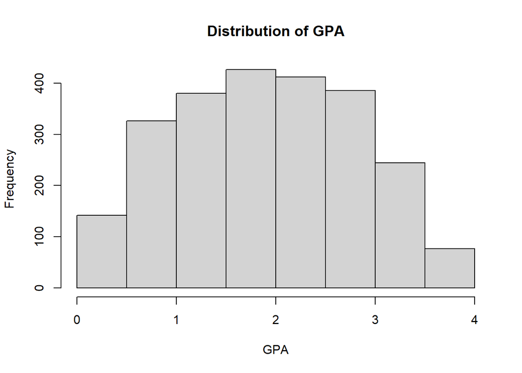

```r
hist(student$GPA,
     main = "Distribution of GPA",
     xlab = "GPA")
```

This histogram shows the distribution of GPA among students.

## Study Time vs GPA

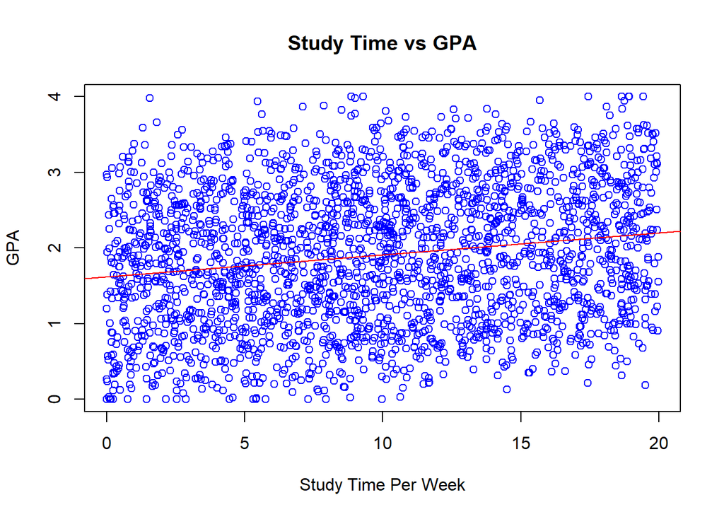

```r
plot(student$StudyTimeWeekly,
     student$GPA,
     main = "Study Time vs GPA",
     xlab = "Study Time Per Week",
     ylab = "GPA",
     col = "blue")

abline(
  lm(GPA ~ StudyTimeWeekly, data = student),
  col = "red"
)
```

This graph shows the relationship between study time and GPA. there is a very slight correlation.

## Absences vs GPA

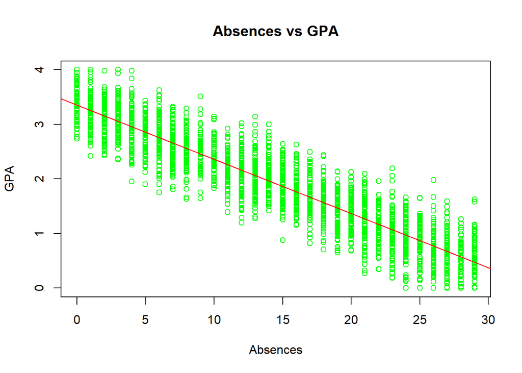

```r
plot(student$Absences,
     student$GPA,
     main = "Absences vs GPA",
     xlab = "Absences",
     ylab = "GPA",
     col = "green")

abline(
  lm(GPA ~ Absences, data = student),
  col = "red"
)
```

This graph shows a strong correlation between absences and GPA.

## GPA with Parental Support

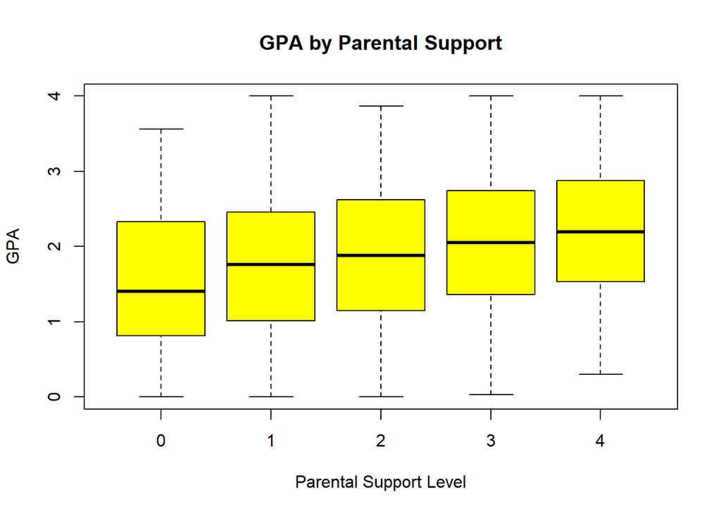

```r
boxplot(GPA ~ ParentalSupport,
        data = student,
        main = "GPA by Parental Support",
        xlab = "Parental Support Level",
        ylab = "GPA",
        col = "yellow")
```

## GPA with Tutoring

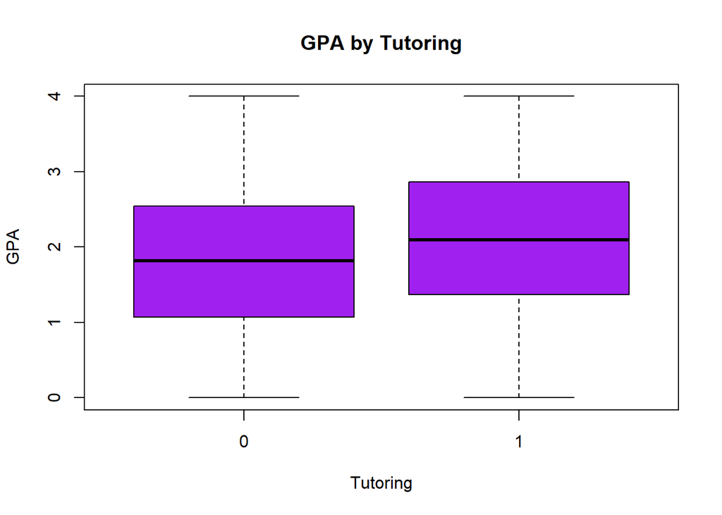

```r
boxplot(GPA ~ Tutoring,
        data = student,
        main = "GPA by Tutoring",
        xlab = "Tutoring",
        ylab = "GPA",
        col = "purple")
```

This graph shows a positive correlation between getting tutored and GPA.

# Correlation Analysis

```r
cor(student[, c(
  "GPA",
  "StudyTimeWeekly",
  "Absences",
  "ParentalEducation",
  "ParentalSupport"
)])
```

```
##                           GPA StudyTimeWeekly     Absences ParentalEducation
## GPA                1.00000000     0.179275127 -0.919313576       -0.03585364
## StudyTimeWeekly    0.17927513     1.000000000  0.009325535       -0.01105118
## Absences          -0.91931358     0.009325535  1.000000000        0.03651750
## ParentalEducation -0.03585364    -0.011051182  0.036517503        1.00000000
## ParentalSupport    0.19077373     0.035799964  0.002107808       -0.01746304
##                   ParentalSupport
## GPA                   0.190773728
## StudyTimeWeekly       0.035799964
## Absences              0.002107808
## ParentalEducation    -0.017463038
## ParentalSupport       1.000000000
```

The correlation matrix shows the relationships between GPA and several important variables.

# Simple Regression Model

```r
model1 <- lm(
  GPA ~ StudyTimeWeekly,
  data = student
)

summary(model1)
```

```
##
## Call:
## lm(formula = GPA ~ StudyTimeWeekly, data = student)
##
## Residuals:
##      Min       1Q   Median       3Q      Max
## -1.99922 -0.73441 -0.00121  0.72442  2.31142
##
## Coefficients:
##                 Estimate Std. Error t value Pr(>|t|)
## (Intercept)     1.622567   0.036777  44.119   <2e-16 ***
## StudyTimeWeekly 0.029024   0.003258   8.909   <2e-16 ***
## ---
## Signif. codes:  0 '***' 0.001 '**' 0.01 '*' 0.05 '.' 0.1 ' ' 1
##
## Residual standard error: 0.9005 on 2390 degrees of freedom
## Multiple R-squared:  0.03214,    Adjusted R-squared:  0.03173
## F-statistic: 79.36 on 1 and 2390 DF,  p-value: < 2.2e-16
```

This model uses study time as the only predictor of GPA.

# Multiple Regression Model

```r
model2 <- lm(
  GPA ~ StudyTimeWeekly +
        Absences +
        ParentalEducation +
        ParentalSupport +
        Tutoring +
        Extracurricular +
        Sports +
        Music +
        Volunteering,
  data = student
)

summary(model2)
```

```
##
## Call:
## lm(formula = GPA ~ StudyTimeWeekly + Absences + ParentalEducation +
##     ParentalSupport + Tutoring + Extracurricular + Sports + Music +
##     Volunteering, data = student)
##
## Residuals:
##      Min       1Q   Median       3Q      Max
## -0.88700 -0.13851  0.00441  0.14221  0.60604
##
## Coefficients:
##                     Estimate Std. Error  t value Pr(>|t|)
## (Intercept)        2.5157005  0.0156503  160.745   <2e-16 ***
## StudyTimeWeekly    0.0289375  0.0007130   40.588   <2e-16 ***
## Absences          -0.0997690  0.0004761 -209.539   <2e-16 ***
## ParentalEducation  0.0017157  0.0040299    0.426    0.670
## ParentalSupport    0.1513589  0.0035891   42.172   <2e-16 ***
## Tutoring           0.2496798  0.0087851   28.421   <2e-16 ***
## Extracurricular    0.1908995  0.0082787   23.059   <2e-16 ***
## Sports             0.1944743  0.0087605   22.199   <2e-16 ***
## Music              0.1431848  0.0101369   14.125   <2e-16 ***
## Volunteering      -0.0086742  0.0110732   -0.783    0.433
## ---
## Signif. codes:  0 '***' 0.001 '**' 0.01 '*' 0.05 '.' 0.1 ' ' 1
##
## Residual standard error: 0.1968 on 2382 degrees of freedom
## Multiple R-squared:  0.9539, Adjusted R-squared:  0.9538
## F-statistic:  5483 on 9 and 2382 DF,  p-value: < 2.2e-16
```

This model uses multiple factors to predict GPA.

# Predicted vs Actual GPA

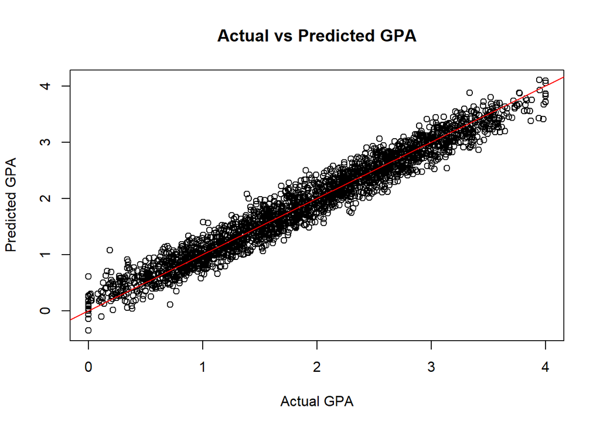

```r
student$PredictedGPA <- predict(model2)

plot(student$GPA,
     student$PredictedGPA,
     main = "Actual vs Predicted GPA",
     xlab = "Actual GPA",
     ylab = "Predicted GPA")

abline(0, 1, col = "red")
```

If the model is correct, the point will be close to the red line.

# Conclusion

This project examined factors associated with student academic success. GPA was used as the measure of academic performance. Exploratory data analysis, correlation analysis, and regression modeling were used to investigate relationships between student characteristics and GPA.

The results indicate that study time, absences, parental support, and other educational factors contribute to academic performance. The multiple regression model provided a stronger explanation of GPA than any single variable alone, suggesting that student success is influenced by multiple factors working together.